# Statistical learning: Advanced - M2 TIDE

*Saleha BHAYAT & Alessandro PITZOLU & Sophia YALAP*

# Introduction

This report is part of the Advanced Statistical Learning course of the Master 2 TIDE. We have two datasets that combine both quantitative and qualitative data. The goal of this study is to apply techniques that address the problems posed by our data types such as ACM or AFMD for example, combined with other learning approaches for clustering.

# Part 1 : Bank Database

```python
import pandas as pd
import seaborn as sns
import statsmodels.api as sm
from scipy.cluster.hierarchy import dendrogram , linkage
import matplotlib.pyplot as plt
from sklearn.cluster import AgglomerativeClustering, DBSCAN, OPTICS
import numpy as np
from sklearn.preprocessing import StandardScaler
from sklearn.decomposition import PCA
import prince
from prince import MCA
import gower
import scipy

import warnings
warnings.filterwarnings("ignore")

pd.set_option('display.max_columns', None)

from IPython.display import display, HTML
display(HTML("<style>.container { width:90% !important; }</style>"))
```

### Variables meaning :

- Customer_ID
- Status_checking_Acc :
  - A11 : < 0 USD
  - A12 : between 0 and 10000 USD
  - A13 : > 10000
  - A14 : no checking account
- Duration_in_Months
- Credit_History:
  - A30: no credits taken/all credits paid back duly
  - A31: all credits at this bank paid back duly
  - A32: existing credits paid back duly till now
  - A33: delay in paying off in the past
  - A34: critical account/other credits existing(not at this bank)
- Purpose_Credit_Taken:
  - A40: car (new)
  - A41: car (used)
  - A42: furniture/equipment
  - A43: radio/television
  - A44: domestic appliances
  - A45: repairs
  - A46: education
  - A47: (vacation - does not exist?)
  - A48: retraining
  - A49: business
  - A410: others
- Credit_Amount
- Savings_Acc:
  - A61: … < 1000 USD
  - A62: 1000 <= … < 5000 USD
  - A63: 5000 <= … < 10000 USD
  - A64: .. >= 10000 USD
  - A65: unknown/ no savings account
- Years_At_Present_Employment:
  - A71: unemployed
  - A72: … < 1 year
  - A73: 1 <= … < 4 years
  - A74: 4 <= … < 7 years
  - A75: .. >= 7 years
- Inst_Rt_Income: installment rate in percentage of disposable income
- Marital_Status_Gender:
  - A91: male : divorced/separated
  - A92: female: divorced/separated/married
  - A93: male : single
  - A94: male : married/widowed
  - A95: female: single
- Other_Debtors_Guarantors:
  - A101: none
  - A102: co-applicant
  - A103: guarantor
- Current_Address_Yrs : Present residence since
- Property:
  - A121: real estate
  - A122: if not A121: building society savings agreement/life insurance
  - A123: if not A121/A122: car or other, not in attribute 6
  - A124: unknown / no property
- Age: age in years
- Other_Inst_Plans: Other installment plans
  - A141: bank
  - A142: stores
  - A143: none
- Housing:
  - A151: rent
  - A152: own
  - A153: for free
- Num_CC: number of existing credits at this bank
- Job:
  - A171: unemployed/ unskilled - non-resident
  - A172: unskilled - resident
  - A173: skilled employee / official
  - A174: management/ self-employed/highly qualified employee/ officer
- Dependents: number of people being liable to provide maintenance for
- Telephone:
  - A191: none
  - A192: yes, registered under the customer’s name
- Foreign_Worker:
  - A201: yes
  - A202: no
- Default_On_Payment:
  - 0 : no default
  - 1 : default

```python
# Analyse de clustering sur Duration_in_Months and Credit_Amount. CAn we get the two clusters of the defaults(0,1)?
bank = pd.read_excel("C:/Users/Yalap/Documents/Cours/M2 TIDE/S2/Apprentissage statistique avancé/Projet/DataBankCredit/DataBank.xlsx", header=2)
bank = bank.drop(columns=["Unnamed: 0"])
bank.head()
```

|  | Customer_ID | Status_Checking_Acc | Duration_in_Months | Credit_History | Purposre_Credit_Taken | Credit_Amount | Savings_Acc | Years_At_Present_Employment | Inst_Rt_Income | Marital_Status_Gender | Other_Debtors_Guarantors | Current_Address_Yrs | Property | Age | Other_Inst_Plans | Housing | Num_CC | Job | Dependents | Telephone | Foreign_Worker | Default_On_Payment | Count |
| --- | --- | --- | --- | --- | --- | --- | --- | --- | --- | --- | --- | --- | --- | --- | --- | --- | --- | --- | --- | --- | --- | --- | --- |
| 0 | 100001 | A11 | 6 | A34 | A43 | 1169 | A65 | A75 | 4 | A93 | A101 | 4 | A121 | 67 | A143 | A152 | 2 | A173 | 1 | A192 | A201 | 0 | 1 |
| 1 | 100002 | A12 | 48 | A32 | A43 | 5951 | A61 | A73 | 2 | A92 | A101 | 2 | A121 | 22 | A143 | A152 | 1 | A173 | 1 | A191 | A201 | 0 | 1 |
| 2 | 100003 | A14 | 12 | A34 | A46 | 2096 | A61 | A74 | 2 | A93 | A101 | 3 | A121 | 49 | A143 | A152 | 1 | A172 | 2 | A191 | A201 | 0 | 1 |
| 3 | 100004 | A11 | 42 | A32 | A42 | 7882 | A61 | A74 | 2 | A93 | A103 | 4 | A122 | 45 | A143 | A153 | 1 | A173 | 2 | A191 | A201 | 0 | 1 |
| 4 | 100005 | A11 | 24 | A33 | A40 | 4870 | A61 | A73 | 3 | A93 | A101 | 4 | A124 | 53 | A143 | A153 | 2 | A173 | 2 | A191 | A201 | 1 | 1 |

```python
bank.columns
```

```
Index(['Customer_ID', 'Status_Checking_Acc', 'Duration_in_Months',
       'Credit_History', 'Purposre_Credit_Taken', 'Credit_Amount',
       'Savings_Acc', 'Years_At_Present_Employment', 'Inst_Rt_Income',
       'Marital_Status_Gender', 'Other_Debtors_Guarantors',
       'Current_Address_Yrs', 'Property', 'Age', 'Other_Inst_Plans ',
       'Housing', 'Num_CC', 'Job', 'Dependents', 'Telephone', 'Foreign_Worker',
       'Default_On_Payment', 'Count'],
      dtype='object')
```

```python
bank.info()
```

```
<class 'pandas.core.frame.DataFrame'>
RangeIndex: 5000 entries, 0 to 4999
Data columns (total 23 columns):
 #   Column                       Non-Null Count  Dtype
---  ------                       --------------  -----
 0   Customer_ID                  5000 non-null   int64
 1   Status_Checking_Acc          5000 non-null   object
 2   Duration_in_Months           5000 non-null   int64
 3   Credit_History               5000 non-null   object
 4   Purposre_Credit_Taken        5000 non-null   object
 5   Credit_Amount                5000 non-null   int64
 6   Savings_Acc                  5000 non-null   object
 7   Years_At_Present_Employment  5000 non-null   object
 8   Inst_Rt_Income               5000 non-null   int64
 9   Marital_Status_Gender        5000 non-null   object
 10  Other_Debtors_Guarantors     5000 non-null   object
 11  Current_Address_Yrs          5000 non-null   int64
 12  Property                     5000 non-null   object
 13  Age                          5000 non-null   int64
 14  Other_Inst_Plans             5000 non-null   object
 15  Housing                      5000 non-null   object
 16  Num_CC                       5000 non-null   int64
 17  Job                          5000 non-null   object
 18  Dependents                   5000 non-null   int64
 19  Telephone                    5000 non-null   object
 20  Foreign_Worker               5000 non-null   object
 21  Default_On_Payment           5000 non-null   int64
 22  Count                        5000 non-null   int64
dtypes: int64(10), object(13)
memory usage: 898.6+ KB
```

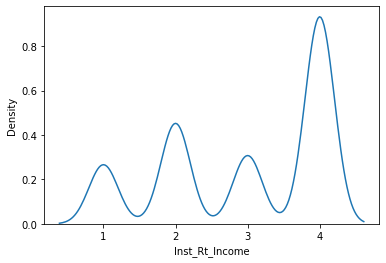

```python
sns.kdeplot(bank["Inst_Rt_Income"]);
```

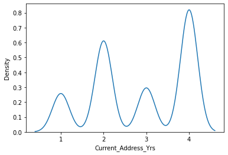

```python
sns.kdeplot(bank["Current_Address_Yrs"]);
```

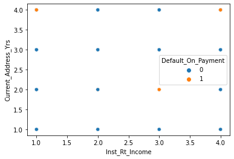

```python
sns.scatterplot(data=bank, x="Inst_Rt_Income", y="Current_Address_Yrs", hue="Default_On_Payment");
```

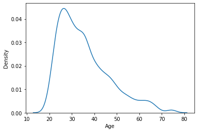

```python
sns.kdeplot(bank["Age"]);
```

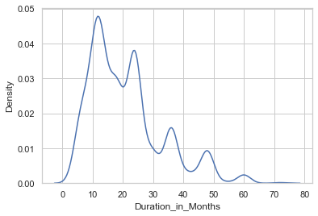

```python
sns.kdeplot(bank["Duration_in_Months"]);
```

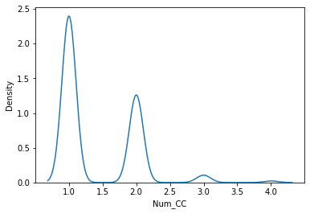

```python
sns.kdeplot(bank["Num_CC"]);
```

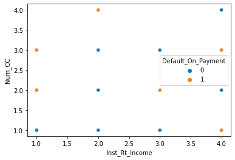

```python
sns.scatterplot(data=bank, x="Inst_Rt_Income", y="Num_CC", hue="Default_On_Payment");
```

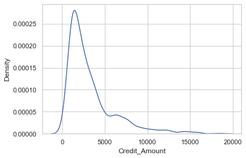

```python
sns.kdeplot(bank["Credit_Amount"]);
```

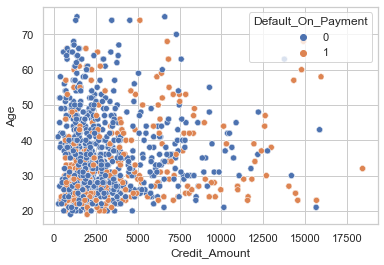

```python
sns.scatterplot(data=bank, x="Credit_Amount", y="Age", hue="Default_On_Payment");
```

In this last few scatter plots we checked if the cluster of observations linked to a default were distinguishable on a 2-D scatter but it doesn't seem to be the case.

## Logistic regression on quantitative variables to see correlation to the Default_On_Payment.

Here we are only using quantitative variables and we want to have an idea on which variables are more determinant in the possibility to have a default.

```python
quant = bank.select_dtypes(include='number')
quant = quant.drop(columns=["Customer_ID","Count","Default_On_Payment"])
```

```python
Y = bank["Default_On_Payment"]
logit_model=sm.Logit(Y,quant)
result=logit_model.fit()
print(result.summary2())
```

```
Optimization terminated successfully.
         Current function value: 0.586353
         Iterations 5
                          Results: Logit
===================================================================
Model:              Logit              Pseudo R-squared: 0.039
Dependent Variable: Default_On_Payment AIC:              5877.5320
Date:               2022-07-06 15:45   BIC:              5923.1524
No. Observations:   5000               Log-Likelihood:   -2931.8
Df Model:           6                  LL-Null:          -3050.1
Df Residuals:       4993               LLR p-value:      2.9663e-48
Converged:          1.0000             Scale:            1.0000
No. Iterations:     5.0000
-------------------------------------------------------------------
                     Coef.  Std.Err.    z    P>|z|   [0.025  0.975]
-------------------------------------------------------------------
Duration_in_Months   0.0221   0.0034  6.4504 0.0000  0.0154  0.0289
Credit_Amount        0.0001   0.0000  3.6511 0.0003  0.0000  0.0001
Inst_Rt_Income       0.0891   0.0283  3.1471 0.0016  0.0336  0.1446
Current_Address_Yrs -0.0206   0.0284 -0.7233 0.4695 -0.0762  0.0351
Age                 -0.0292   0.0031 -9.5869 0.0000 -0.0352 -0.0233
Num_CC              -0.2958   0.0572 -5.1752 0.0000 -0.4078 -0.1838
Dependents          -0.2278   0.0827 -2.7562 0.0058 -0.3899 -0.0658
===================================================================
```

If we look at the Pseudo R-squared we can see that with only these quantitative variables we can explain a small proportion of the probability of Default on payments. Then if we look at the p-values of z, we can see that all these variables are statistically significants in the explaination of the probability of default with the exception of the "Current_Address_Yrs".

## Logistic regression on all variables to see correlation to the Default_On_Payment.

Since by using only quantitative variables we could explain only a small portion of the probability of default, this time we tryed to use all variables.

```python
X = bank.drop(columns=["Customer_ID","Count","Default_On_Payment"])
X = pd.get_dummies(X, columns=["Status_Checking_Acc","Credit_History","Purposre_Credit_Taken","Savings_Acc","Years_At_Present_Employment"
                              ,"Marital_Status_Gender","Other_Debtors_Guarantors","Property","Other_Inst_Plans ","Housing","Job",
                              "Telephone","Foreign_Worker"], drop_first=True)
logit_model=sm.Logit(Y,X)
result=logit_model.fit()
print(result.summary2())
```

```
Optimization terminated successfully.
         Current function value: 0.448443
         Iterations 7
                                 Results: Logit
================================================================================
Model:                  Logit                  Pseudo R-squared:     0.265
Dependent Variable:     Default_On_Payment     AIC:                  4580.4279
Date:                   2022-07-06 15:45       BIC:                  4893.2531
No. Observations:       5000                   Log-Likelihood:       -2242.2
Df Model:               47                     LL-Null:              -3050.1
Df Residuals:           4952                   LLR p-value:          7.0673e-308
Converged:              1.0000                 Scale:                1.0000
No. Iterations:         7.0000
--------------------------------------------------------------------------------
                                 Coef.  Std.Err.    z     P>|z|   [0.025  0.975]
--------------------------------------------------------------------------------
Duration_in_Months               0.0263   0.0041   6.3457 0.0000  0.0182  0.0345
Credit_Amount                    0.0001   0.0000   6.6288 0.0000  0.0001  0.0002
Inst_Rt_Income                   0.3419   0.0390   8.7787 0.0000  0.2656  0.4183
Current_Address_Yrs              0.0110   0.0383   0.2875 0.7737 -0.0640  0.0860
Age                             -0.0131   0.0039  -3.3402 0.0008 -0.0208 -0.0054
Num_CC                           0.2925   0.0803   3.6414 0.0003  0.1350  0.4499
Dependents                       0.2827   0.1082   2.6119 0.0090  0.0706  0.4949
Status_Checking_Acc_A12         -0.3864   0.0963  -4.0115 0.0001 -0.5751 -0.1976
Status_Checking_Acc_A13         -0.9455   0.1636  -5.7803 0.0000 -1.2661 -0.6249
Status_Checking_Acc_A14         -1.7081   0.1037 -16.4716 0.0000 -1.9113 -1.5048
Credit_History_A31               0.2037   0.2267   0.8989 0.3687 -0.2405  0.6480
Credit_History_A32              -0.5329   0.1726  -3.0884 0.0020 -0.8712 -0.1947
Credit_History_A33              -0.8014   0.2014  -3.9792 0.0001 -1.1961 -0.4067
Credit_History_A34              -1.3910   0.1856  -7.4940 0.0000 -1.7548 -1.0272
Purposre_Credit_Taken_A41       -1.6542   0.1672  -9.8963 0.0000 -1.9819 -1.3266
Purposre_Credit_Taken_A410      -1.4526   0.3452  -4.2074 0.0000 -2.1292 -0.7759
Purposre_Credit_Taken_A42       -0.7695   0.1151  -6.6860 0.0000 -0.9951 -0.5439
Purposre_Credit_Taken_A43       -0.9060   0.1103  -8.2141 0.0000 -1.1222 -0.6898
Purposre_Credit_Taken_A44       -0.4996   0.3392  -1.4730 0.1408 -1.1644  0.1652
Purposre_Credit_Taken_A45       -0.1999   0.2449  -0.8162 0.4144 -0.6799  0.2801
Purposre_Credit_Taken_A46        0.0371   0.1767   0.2101 0.8336 -0.3093  0.3835
Purposre_Credit_Taken_A48       -2.0767   0.5426  -3.8272 0.0001 -3.1402 -1.0132
Purposre_Credit_Taken_A49       -0.7064   0.1468  -4.8133 0.0000 -0.9941 -0.4188
Savings_Acc_A62                 -0.3412   0.1278  -2.6694 0.0076 -0.5918 -0.0907
```

[output cut: 10 more lines]

```
Other_Debtors_Guarantors_A102    0.4458   0.1832   2.4336 0.0149  0.0868  0.8048
Other_Debtors_Guarantors_A103   -0.9453   0.1895  -4.9873 0.0000 -1.3168 -0.5738
Property_A122                    0.3146   0.1130   2.7846 0.0054  0.0932  0.5360
Property_A123                    0.2430   0.1051   2.3111 0.0208  0.0369  0.4490
Property_A124                    0.7757   0.1884   4.1169 0.0000  0.4064  1.1449
Other_Inst_Plans _A142          -0.1024   0.1837  -0.5575 0.5772 -0.4624  0.2576
Other_Inst_Plans _A143          -0.6256   0.1040  -6.0156 0.0000 -0.8294 -0.4217
Housing_A152                    -0.4425   0.1036  -4.2702 0.0000 -0.6456 -0.2394
Housing_A153                    -0.6930   0.2127  -3.2579 0.0011 -1.1100 -0.2761
Job_A172                         0.6411   0.2786   2.3008 0.0214  0.0950  1.1872
Job_A173                         0.6502   0.2640   2.4623 0.0138  0.1326  1.1677
Job_A174                         0.5758   0.2685   2.1450 0.0320  0.0497  1.1020
Telephone_A192                  -0.2970   0.0897  -3.3103 0.0009 -0.4729 -0.1212
Foreign_Worker_A202             -1.3815   0.2779  -4.9707 0.0000 -1.9262 -0.8368
================================================================================
```

Even with the use of all variables we can't have a pseudo-R squared above 30%, anyway the logistic regression has significally improved compared to the previous version with only quantitative variables.

## Dendrograms to see the number of possible clusters

Before trying to do some clustering on the 2 dimensianal space delineated by the variables "Age" and "Credit_Amount", we tryed to identify the number of possible clusters with the help of 4 different dendrograms computed with the ward, single, complete and average methods.

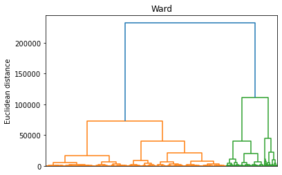

```python
agecredit = quant.iloc[:,[1,4]]
Z = linkage(agecredit, method = 'ward')
#plotting dendrogram
dendro = dendrogram(Z,no_labels=True)
plt.title('Ward')
plt.ylabel('Euclidean distance')
plt.show()
```

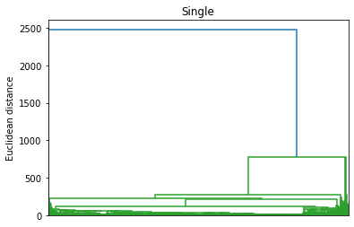

```python
Z = linkage(agecredit, method = 'single')
#plotting dendrogram
dendro = dendrogram(Z,no_labels=True)
plt.title('Single')
plt.ylabel('Euclidean distance')
plt.show()
```

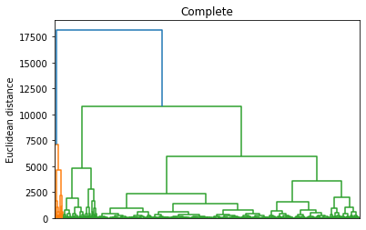

```python
Z = linkage(agecredit, method = 'complete')
#plotting dendrogram
dendro = dendrogram(Z,no_labels=True)
plt.title('Complete')
plt.ylabel('Euclidean distance')
plt.show()
```

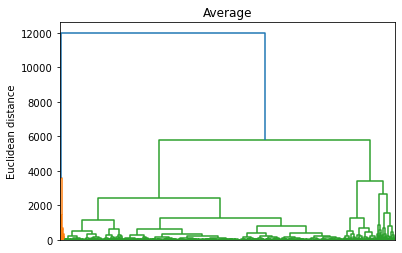

```python
Z = linkage(agecredit, method = 'average')
#plotting dendrogram
dendro = dendrogram(Z,no_labels=True)
plt.title('Average')
plt.ylabel('Euclidean distance')
plt.show()
```

Apart from ward's method dendrogram, all the graphs have one cluster all the way to the left and then a large ramification on the right which starts at different points according to the method but that follows a similar path. Ward's method computed dendrogram has 2 initial ramifications, then it starts ramificating on the right and then on the left. What they have in common is that in general the first ramification (2 clusters) is the longest one, for this reason we tryed to look for 2 clusters with the clustering techniques we used.

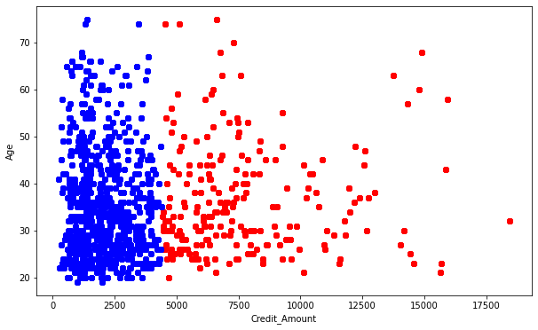

```python
agg_clustering = AgglomerativeClustering(n_clusters = 2, affinity = 'euclidean', linkage = 'ward')

#predicting the labels

labels = agg_clustering.fit_predict(agecredit)

#Plotting the results

plt.figure(figsize = (10,6))
plt.scatter(agecredit.values[labels == 0 , 0] , agecredit.values[labels == 0 , 1] , c = 'red')
plt.scatter(agecredit.values[labels == 1 , 0] , agecredit.values[labels == 1 , 1] , c = 'blue')
# plt.scatter(agecredit.values[labels == 2 , 0] , agecredit.values[labels == 2 , 1] , c = 'green')
# plt.scatter(agecredit.values[labels == 3 , 0] , agecredit.values[labels == 3 , 1] , c = 'yellow')
plt.xlabel("Credit_Amount")
plt.ylabel("Age")
plt.show()
```

This first clustering was made with agglomerative clustering and it gives us a a line between the two clusters at a level of credit around 4500.

### Computing Gower's distance matrix

https://medium.com/analytics-vidhya/gowers-distance-899f9c4bd553

Since we have both quantitative and qualitative variables, computing distances with qualitative variables as usual is not possible. For this reason we looked for other approaches and we found Gower's distance matrix that can cumpute distances even when we have qualitative variables.

```python
tester = quant
tester["Purposre_Credit_Taken"] = bank["Purposre_Credit_Taken"]
distance_matrix = gower.gower_matrix(tester, cat_features = [False,False,False,False,False,False,False,True])
```

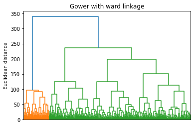

```python
Zd = linkage(distance_matrix,  method = 'ward')
dendro = dendrogram(Zd, no_labels=True)
plt.title('Gower with ward linkage')
plt.ylabel('Euclidean distance')
plt.show()
```

```python
agg2 = AgglomerativeClustering(affinity = 'precomputed', n_clusters = 2, linkage="average")
agg2.fit(distance_matrix)
labels = agg2.labels_
```

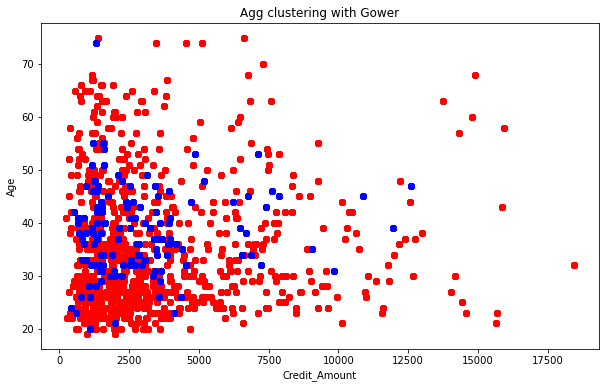

```python
plt.figure(figsize = (10,6))
plt.scatter(agecredit.values[labels == 0 , 0] , agecredit.values[labels == 0 , 1] , c = 'red')
plt.scatter(agecredit.values[labels == 1 , 0] , agecredit.values[labels == 1 , 1] , c = 'blue')
# plt.scatter(agecredit.values[labels == 2 , 0] , agecredit.values[labels == 2 , 1] , c = 'green')
# plt.scatter(agecredit.values[labels == 3 , 0] , agecredit.values[labels == 3 , 1] , c = 'yellow')
plt.title('Agg clustering with Gower')
plt.xlabel("Credit_Amount")
plt.ylabel("Age")
plt.show()
```

```python
tester = pd.get_dummies(tester, columns=["Purposre_Credit_Taken"], drop_first=True)
testscaled = StandardScaler().fit_transform(tester)
pca = PCA(n_components=2)
principalComponents = pca.fit_transform(testscaled)
principalDf = pd.DataFrame(data = principalComponents, columns = ['principal component 1', 'principal component 2'])
```

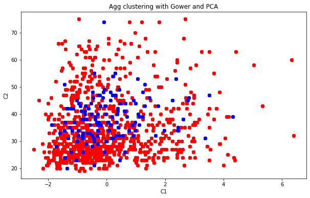

```python
plt.figure(figsize = (10,6))
plt.scatter(principalDf.values[labels == 0 , 0] , agecredit.values[labels == 0 , 1] , c = 'red')
plt.scatter(principalDf.values[labels == 1 , 0] , agecredit.values[labels == 1 , 1] , c = 'blue')
# plt.scatter(agecredit.values[labels == 2 , 0] , agecredit.values[labels == 2 , 1] , c = 'green')
# plt.scatter(agecredit.values[labels == 3 , 0] , agecredit.values[labels == 3 , 1] , c = 'yellow')
plt.title('Agg clustering with Gower and PCA')
plt.xlabel("C1")
plt.ylabel("C2")
plt.show()
```

### Optics Clustering (derived from DBSCAN)

https://en.wikipedia.org/wiki/OPTICS_algorithm

Since we weren't satisfied by the clustering made with the agglomerative clustering algorithm we tryed other techniques. Here for example we tryed optics clustering which is derived from DBSCAN but allows differentiated cluster densities.

```python
optics_clustering = OPTICS(min_samples=100, metric="precomputed").fit(distance_matrix)
labelopt = optics_clustering.labels_
```

```python
np.unique(labelopt)
```

```
array([-1,  0,  1,  2])
```

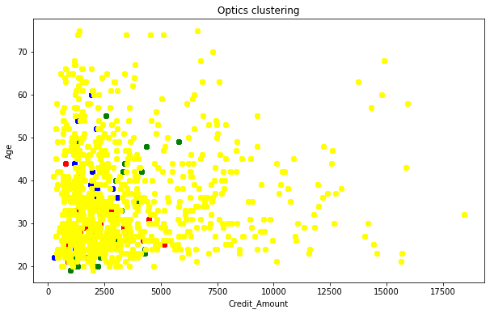

```python
plt.figure(figsize = (10,6))
plt.scatter(agecredit.values[labelopt == 0 , 0] , agecredit.values[labelopt == 0 , 1] , c = 'red')
plt.scatter(agecredit.values[labelopt == 1 , 0] , agecredit.values[labelopt == 1 , 1] , c = 'blue')
plt.scatter(agecredit.values[labelopt == 2 , 0] , agecredit.values[labelopt == 2 , 1] , c = 'green')
plt.scatter(agecredit.values[labelopt == -1 , 0] , agecredit.values[labelopt == -1 , 1] , c = 'yellow')
plt.title('Optics clustering')
plt.xlabel("Credit_Amount")
plt.ylabel("Age")
plt.show()
```

## MCA

Here we wanted to do Multiple Correspondence Analysis on some of the qualitative variables present in the Bank's dataset. The variables we used are the "Purposre_Credit_Taken", "Foreign_Worker", "Default_On_Payment" and "Credit_History" renominated as "Deafault", "Purpose", "Foreign" and "History".

```python
qual = bank.loc[:,["Purposre_Credit_Taken","Foreign_Worker","Default_On_Payment","Credit_History"]]
qual['Default'] = qual['Default_On_Payment'].replace([1,0],["Yes","No"])
qual['Purpose'] = qual['Purposre_Credit_Taken'].replace(["A40","A41","A42","A43","A44","A45","A46","A47","A48","A49","A410"],
                                                        ["Newcar","Usedcar","Furniture","TV","appliances","repairs","edu","vacation",
                                                         "retraining","business","other"])
qual['Foreign'] = qual['Foreign_Worker'].replace(["A201","A202"],["Yes","No"])
qual['History'] = qual['Credit_History'].replace(["A30","A31","A32","A33","A34"],["no/paid","paid_here","paid_tillnow","delay","critical"])
qual=qual.drop(columns=["Purposre_Credit_Taken","Credit_History","Foreign_Worker","Default_On_Payment"])
qual.head()
```

|  | Default | Purpose | Foreign | History |
| --- | --- | --- | --- | --- |
| 0 | No | TV | Yes | critical |
| 1 | No | TV | Yes | paid_tillnow |
| 2 | No | edu | Yes | critical |
| 3 | No | Furniture | Yes | paid_tillnow |
| 4 | Yes | Newcar | Yes | delay |

```python
mca = MCA(n_components = 2)
mca.fit(qual)
data_mca = mca.transform(qual)
data_mca.head()
```

|  | 0 | 1 |
| --- | --- | --- |
| 0 | -0.636725 | -0.439566 |
| 1 | -0.426890 | -0.174035 |
| 2 | -0.300778 | -0.218781 |
| 3 | -0.216421 | 0.186476 |
| 4 | 0.827060 | -0.057544 |

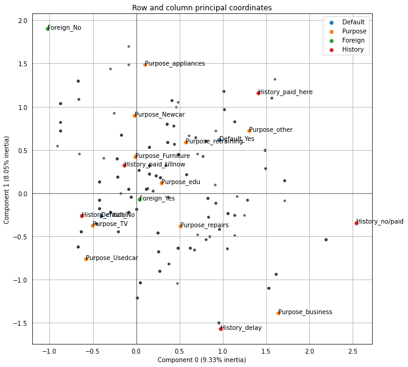

```python
#Représentation graphique
mca.plot_coordinates(qual,
                     row_points_alpha=.2,
                     figsize=(10, 10),
                     show_column_labels=True,
                     show_row_points=True
                    );
```

```python
mca.eigenvalues_
```

```
[0.3499083471351053, 0.3019833047978772]
```

The MCA gives us a picture where a delay in payment's history are close to loans given for business purposes while those paid are closer to other purposes

## FAMD

Check slides, pratically have to standardise quant data and to center qual data. In order to center get f+j = sum(along column j) /n. Then each value/sqrt(f+j).

```python
quant=quant.drop(columns=["Purposre_Credit_Taken"])
quantscal = pd.DataFrame(StandardScaler().fit_transform(quant),columns=quant.columns)
dummo=pd.get_dummies(qual)
centro=dummo
```

```python
for i in range(19):
    centro.iloc[:,i]=centro.iloc[:,i]/(np.sqrt(sum(centro.iloc[:,i])/len(centro)))
```

```python
famd = pd.concat([quantscal, centro], axis=1)
famd.head()
```

|  | Duration_in_Months | Credit_Amount | Inst_Rt_Income | Current_Address_Yrs | Age | Num_CC | Dependents | Default_No | Default_Yes | Purpose_Furniture | ... | Purpose_other | Purpose_repairs | Purpose_retraining | Foreign_No | Foreign_Yes | History_critical | History_delay | History_no/paid | History_paid_here | History_paid_tillnow |
| --- | --- | --- | --- | --- | --- | --- | --- | --- | --- | --- | --- | --- | --- | --- | --- | --- | --- | --- | --- | --- | --- |
| 0 | -1.236478 | -0.745131 | 0.918477 | 1.046987 | 2.766456 | 1.027079 | -0.428290 | 1.194376 | 0.000000 | 0.000000 | ... | 0.0 | 0.0 | 0.0 | 0.0 | 1.01903 | 1.847422 | 0.000000 | 0.0 | 0.0 | 0.000000 |
| 1 | 2.248194 | 0.949817 | -0.870183 | -0.765977 | -1.191404 | -0.704926 | -0.428290 | 1.194376 | 0.000000 | 0.000000 | ... | 0.0 | 0.0 | 0.0 | 0.0 | 1.01903 | 0.000000 | 0.000000 | 0.0 | 0.0 | 1.373606 |
| 2 | -0.738668 | -0.416562 | -0.870183 | 0.140505 | 1.183312 | -0.704926 | 2.334869 | 1.194376 | 0.000000 | 0.000000 | ... | 0.0 | 0.0 | 0.0 | 0.0 | 1.01903 | 1.847422 | 0.000000 | 0.0 | 0.0 | 0.000000 |
| 3 | 1.750384 | 1.634247 | -0.870183 | 1.046987 | 0.831502 | -0.704926 | 2.334869 | 1.194376 | 0.000000 | 2.350502 | ... | 0.0 | 0.0 | 0.0 | 0.0 | 1.01903 | 0.000000 | 0.000000 | 0.0 | 0.0 | 1.373606 |
| 4 | 0.256953 | 0.566664 | 0.024147 | 1.046987 | 1.535122 | 1.027079 | 2.334869 | 0.000000 | 1.828792 | 0.000000 | ... | 0.0 | 0.0 | 0.0 | 0.0 | 1.01903 | 0.000000 | 3.370999 | 0.0 | 0.0 | 0.000000 |

5 rows × 26 columns

```python
pcs = pca.fit_transform(famd)
pdf = pd.DataFrame(data = pcs, columns = ['PC1', 'PC2'])
```

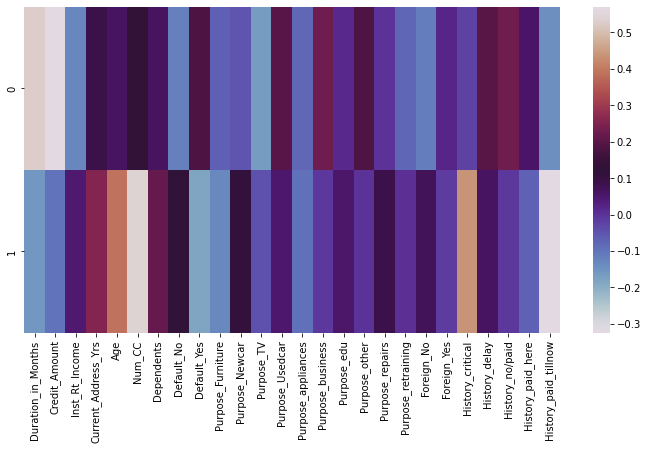

```python
mappa= pd.DataFrame(pca.components_,columns=famd.columns)
plt.figure(figsize=(12,6))
sns.heatmap(mappa,cmap='twilight');
```

```python
plotto = mappa.T
plotto = plotto.reset_index()
```

```python
def scatter_text(x, y, text_column, data, title, xlabel, ylabel):
    """Scatter plot with country codes on the x y coordinates
       Based on this answer: https://stackoverflow.com/a/54789170/2641825"""
    # Create the scatter plot
    p1 = sns.scatterplot(x, y, data=data, size = 8, legend=False)
    # Add text besides each point
    for line in range(0,data.shape[0]):
         p1.text(data[x][line]+0.01, data[y][line],
                 data[text_column][line], horizontalalignment='left',
                 size='large', color='black', weight='semibold')
    # Set title and axis labels
    plt.title(title)
    plt.xlabel(xlabel)
    plt.ylabel(ylabel)
    return p1
```

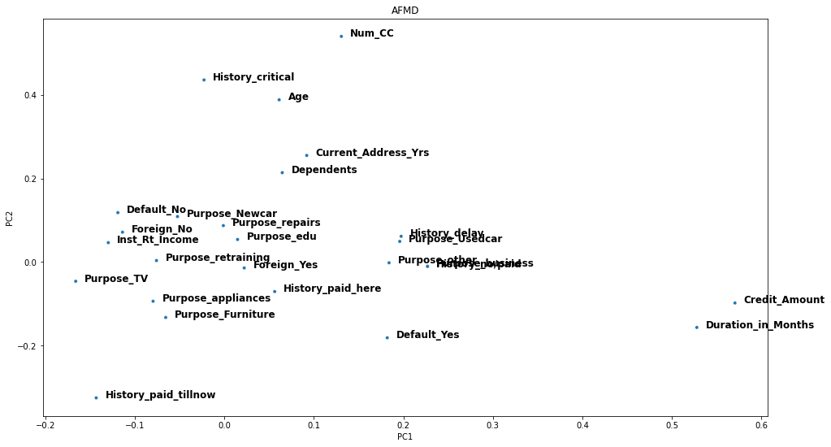

```python
plt.figure(figsize=(16,9))
scatter_text(0, 1,'index' ,
             data = plotto,
             title = 'AFMD',
             xlabel = 'PC1',
             ylabel = 'PC2');
```

As we can see the on the horizontal axis we have a differenciation based on the credit amount and the duration of the credit while the vertical axis is based on credit history and the number of credits with the same creditor.

```python
# original_df the original numeric dataframe
# pca is the model
def create_importance_dataframe(pca, original_df):

    # Change pcs components ndarray to a dataframe
    importance_df  = pd.DataFrame(pca.components_)

    # Assign columns
    importance_df.columns  = original_df.columns

    # Change to absolute values
    importance_df =importance_df.apply(np.abs)

    # Transpose
    importance_df=importance_df.transpose()

    # Change column names again

    ## First get number of pcs
    num_pcs = importance_df.shape[1]

    ## Generate the new column names
    new_columns = [f'PC{i}' for i in range(1, num_pcs + 1)]

    ## Now rename
    importance_df.columns  =new_columns

    # Return importance df
    return importance_df
```

```python
# Call function to create importance df
importance_df  =create_importance_dataframe(pca, famd)
importance_df["PC1perc"] = importance_df["PC1"]/importance_df.sum()[0]
importance_df["PC1perc"] = (importance_df["PC1perc"]*100).round(2).astype(str) + '%'
importance_df["PC2perc"] = importance_df["PC2"]/importance_df.sum()[1]
importance_df["PC2perc"] = (importance_df["PC2perc"]*100).round(2).astype(str) + '%'

# Show first few rows
display(importance_df.head())
```

|  | PC1 | PC2 | PC1perc | PC2perc |
| --- | --- | --- | --- | --- |
| Duration_in_Months | 0.527752 | 0.156429 | 14.18% | 4.38% |
| Credit_Amount | 0.570331 | 0.097880 | 15.33% | 2.74% |
| Inst_Rt_Income | 0.129607 | 0.046533 | 3.48% | 1.3% |
| Current_Address_Yrs | 0.092080 | 0.255380 | 2.47% | 7.14% |
| Age | 0.061314 | 0.388367 | 1.65% | 10.86% |

```python
# Sort depending on PC of interest

## PC1 top 10 important features
pc1_top_10_features = importance_df[['PC1','PC1perc']].sort_values(ascending = False,by='PC1')[:10]
print(), print(f'PC1 top 10 feautres are: \n')
display(pc1_top_10_features)

## PC2 top 10 important features
pc2_top_10_features = importance_df[['PC2','PC2perc']].sort_values(ascending = False,by='PC2')[:10]
print(), print(f'PC2 top 10 feautres are: \n')
display(pc2_top_10_features)
```

```
PC1 top 10 feautres are:
```

|  | PC1 | PC1perc |
| --- | --- | --- |
| Credit_Amount | 0.570331 | 15.33% |
| Duration_in_Months | 0.527752 | 14.18% |
| Purpose_business | 0.226915 | 6.1% |
| History_no/paid | 0.226901 | 6.1% |
| History_delay | 0.197522 | 5.31% |
| Purpose_Usedcar | 0.195920 | 5.26% |
| Purpose_other | 0.184009 | 4.94% |
| Default_Yes | 0.182015 | 4.89% |
| Purpose_TV | 0.165983 | 4.46% |
| History_paid_tillnow | 0.143074 | 3.84% |

```
PC2 top 10 feautres are:
```

|  | PC2 | PC2perc |
| --- | --- | --- |
| Num_CC | 0.540129 | 15.11% |
| History_critical | 0.435972 | 12.2% |
| Age | 0.388367 | 10.86% |
| History_paid_tillnow | 0.324946 | 9.09% |
| Current_Address_Yrs | 0.255380 | 7.14% |
| Dependents | 0.214092 | 5.99% |
| Default_Yes | 0.181176 | 5.07% |
| Duration_in_Months | 0.156429 | 4.38% |
| Purpose_Furniture | 0.132546 | 3.71% |
| Default_No | 0.118325 | 3.31% |